**View in Colab**

# IPL Dataset Analysis

## Problem Statement

We want to know as to what happens during an IPL match which raises several questions in our mind with our limited knowledge about the game called cricket on which it is based. This analysis is done to know as which factors led one of the team to win and how does it matter.

## About the Dataset :

The Indian Premier League (IPL) is a professional T20 cricket league in India contested during April-May of every year by teams representing Indian cities. It is the most-attended cricket league in the world and ranks sixth among all the sports leagues. It has teams with players from around the world and is very competitive and entertaining with a lot of close matches between teams.

The IPL and other cricket related datasets are available at cricsheet.org. Feel free to visit the website and explore the data by yourself as exploring new sources of data is one of the interesting activities a data scientist gets to do.

## About the dataset:

Snapshot of the data you will be working on:  
The dataset 136522 data points and 24 features

| Features | Description |
| --- | --- |
| match_code | Code pertaining to individual match |
| date | Date of the match played |
| city | City where the match was played |
| venue | Stadium in that city where the match was played |
| team1 | team1 |
| team2 | team2 |
| toss_winner | Who won the toss out of two teams |
| toss_decision | toss decision taken by toss winner |
| winner | Winner of that match between two teams |
| win_type | How did the team won(by wickets or runs etc.) |
| win_margin | difference with which the team won |
| inning | inning type(1st or 2nd) |
| delivery | ball delivery |
| batting_team | current team on batting |
| batsman | current batsman on strike |
| non_striker | batsman on non-strike |
| bowler | Current bowler |
| runs | runs scored |
| extras | extra run scored |
| total | total run scored on that delivery including runs and extras |
| extras_type | extra run scored by wides or no ball or legby |
| player_out | player that got out |
| wicket_kind | How did the player got out |
| wicket_fielders | Fielder who caught out the player by catch |

## Load the data

```python
# Read the data using pandas module.
import pandas as pd
import numpy as np

df_ipl = pd.read_csv('../data/ipl_data.csv')
df_ipl.shape
```

```
(136522, 24)
```

## There are matches being played all around the world. Find the list of unique cities where matches are being played throughout the world.

```python
print('Cities these matches were played at',df_ipl.city.unique())
```

```
Cities these matches were played at ['East London' 'Port Elizabeth' 'Centurion' 'neutral_venue' 'Chennai'
 'Jaipur' 'Kolkata' 'Delhi' 'Chandigarh' 'Hyderabad' 'Ranchi' 'Mumbai'
 'Bangalore' 'Dharamsala' 'Pune' 'Rajkot' 'Durban' 'Cuttack' 'Cape Town'
 'Ahmedabad' 'Johannesburg' 'Visakhapatnam' 'Abu Dhabi' 'Raipur' 'Kochi'
 'Kimberley' 'Nagpur' 'Bloemfontein' 'Indore' 'Kanpur']
```

```python
df_ipl.loc[df_ipl.city=='neutral_venue' , 'venue'].unique()
```

```
array(['Dubai International Cricket Stadium', 'Sharjah Cricket Stadium'],
      dtype=object)
```

## Find columns containing null values if any.

```python
df_ipl.info()
```

```
<class 'pandas.core.frame.DataFrame'>
RangeIndex: 136522 entries, 0 to 136521
Data columns (total 24 columns):
 #   Column           Non-Null Count   Dtype
---  ------           --------------   -----
 0   match_code       136522 non-null  int64
 1   date             136522 non-null  object
 2   city             136522 non-null  object
 3   venue            136522 non-null  object
 4   team1            136522 non-null  object
 5   team2            136522 non-null  object
 6   toss_winner      136522 non-null  object
 7   toss_decision    136522 non-null  object
 8   winner           134704 non-null  object
 9   win_type         134704 non-null  object
```

[output cut: 16 more lines]

```python
null_cols = df_ipl.isnull().sum()
print("List of cols with null values",
      null_cols[null_cols > 0].index.to_list())
```

```
List of cols with null values ['winner', 'win_type', 'win_margin', 'extras_type', 'player_out', 'wicket_kind', 'wicket_fielders']
```

#### why we have rows with missing winner

```python
df_ipl.loc[df_ipl.winner.isnull() , 'match_code'].unique()
```

```
array([392190, 598004, 829813, 829741, 419121, 501265, 729315, 829763,
       598017], dtype=int64)
```

## Matches are played throughout the world in different countries but they may or may not have multiple venues(stadiums where matches are played).

```python
city_venue = df_ipl.groupby('city').venue.nunique()
multi_stadium_cities =city_venue[city_venue>1].index.to_list()
multi_stadium_cities

df_ipl.loc[ df_ipl.city.isin(multi_stadium_cities), ].groupby('city').venue.unique().to_dict()
```

```
{'Chandigarh': array(['Punjab Cricket Association Stadium, Mohali',
        'Punjab Cricket Association IS Bindra Stadium, Mohali'],
       dtype=object),
 'Mumbai': array(['Wankhede Stadium', 'Brabourne Stadium',
        'Dr DY Patil Sports Academy'], dtype=object),
 'Pune': array(['Maharashtra Cricket Association Stadium',
        'Subrata Roy Sahara Stadium'], dtype=object),
 'neutral_venue': array(['Dubai International Cricket Stadium', 'Sharjah Cricket Stadium'],
       dtype=object)}
```

## Find the top 5 venues where the most matches are played.

```python
#find the top 5 venuws where the most number of balls were bowled
# df_ipl.venue.value_counts().nlargest(5)
```

```python
df_ipl.groupby('venue').match_code.nunique().nlargest(5)
```

```
venue
M Chinnaswamy Stadium              58
Eden Gardens                       54
Feroz Shah Kotla                   53
Wankhede Stadium                   49
MA Chidambaram Stadium, Chepauk    48
Name: match_code, dtype: int64
```

## Find out how the runs were scored that is the runs count frequency table( number of singles, doubles, boundaries, sixes etc were scored).

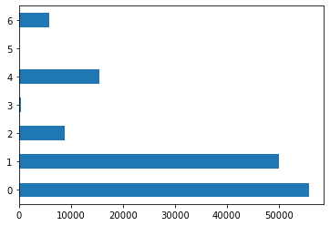

```python
df_ipl.runs.value_counts(sort=False).plot.barh()
```

# is there a difference in runs freq wrt to innings

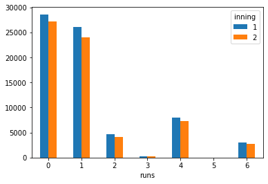

```python
df_ipl.groupby('inning').runs.value_counts(sort=False).unstack().T.plot.bar(rot=0)
```

## IPL seasons are held every year now let's look at our data and extract how many seasons and which year were they played?

```python
df_ipl.date.apply(lambda row:  row[:4])
```

```
0         2009
1         2009
2         2009
3         2009
4         2009
          ...
136517    2008
136518    2008
136519    2008
136520    2008
136521    2008
Name: date, Length: 136522, dtype: object
```

```python
df_ipl['year'] = df_ipl.date.astype('datetime64').dt.year
df_ipl.year
```

```
0         2009
1         2009
2         2009
3         2009
4         2009
          ...
136517    2008
136518    2008
136519    2008
136520    2008
136521    2008
Name: year, Length: 136522, dtype: int64
```

```python
print('number of seasons',df_ipl.year.nunique())
```

```
number of seasons 9
```

```python
print('they were played in ', df_ipl.year.sort_values().unique())
```

```
they were played in  [2008 2009 2010 2011 2012 2013 2014 2015 2016]
```

## Find out the total number of matches played in each season also find the total number of runs scored in each season.

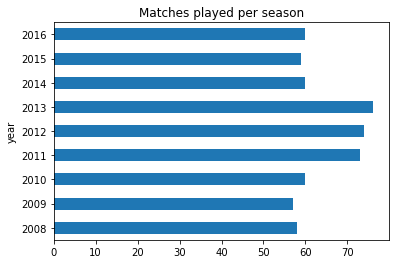

```python
df_ipl.groupby('year').match_code.nunique().plot.barh(title='Matches played per season')
```

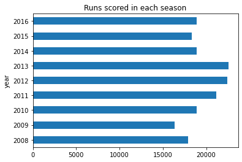

```python
df_ipl.groupby('year').total.sum().plot.barh(title='Runs scored in each season')
```

# avg runs scores per match all seasons

```python
(df_ipl
 .groupby(['match_code'])
 .total.sum()  ### runs scores in each match
 .mean()
)
```

```
303.9272097053726
```

## There are teams which are high performing and low performing. Let's look at the aspect of performance of an individual team. Filter the data and aggregate the runs scored by each team. Display top 10 results which are having runs scored over 200.

```python
total_scores = df_ipl.groupby(['match_code','inning','batting_team']).total.sum().reset_index()
high_scoring_match_codes = total_scores.loc[total_scores.total>=200, 'match_code']
high_scores = total_scores.loc[total_scores.match_code.isin(high_scoring_match_codes),]
high_scores.nlargest(10, columns='total')
```

|  | match_code | inning | batting_team | total |
| --- | --- | --- | --- | --- |
| 701 | 598027 | 1 | Royal Challengers Bangalore | 263 |
| 1118 | 980987 | 1 | Royal Challengers Bangalore | 248 |
| 292 | 419137 | 1 | Chennai Super Kings | 246 |
| 2 | 335983 | 1 | Chennai Super Kings | 240 |
| 1002 | 829795 | 1 | Royal Challengers Bangalore | 235 |
| 472 | 501260 | 1 | Kings XI Punjab | 232 |
| 398 | 501223 | 1 | Delhi Daredevils | 231 |
| 851 | 733987 | 1 | Kings XI Punjab | 231 |
| 1038 | 980907 | 1 | Royal Challengers Bangalore | 227 |
| 911 | 734047 | 1 | Kings XI Punjab | 226 |

## Chasing a 200+ target is difficulty in T-20 format. What are the chances that a team scoring runs above 200 in their 1st inning is chased by the opposition in 2nd inning.

```python
high_scores_1 = high_scores.loc[high_scores.inning==1, :]
high_scores_2 = high_scores.loc[high_scores.inning==2, :]
high_scores_1.head()
```

|  | match_code | inning | batting_team | total |
| --- | --- | --- | --- | --- |
| 0 | 335982 | 1 | Kolkata Knight Riders | 222 |
| 2 | 335983 | 1 | Chennai Super Kings | 240 |
| 14 | 335989 | 1 | Chennai Super Kings | 208 |
| 16 | 335990 | 1 | Deccan Chargers | 214 |
| 64 | 336014 | 1 | Kolkata Knight Riders | 204 |

```python
high_scores_2.head()
```

|  | match_code | inning | batting_team | total |
| --- | --- | --- | --- | --- |
| 1 | 335982 | 2 | Royal Challengers Bangalore | 82 |
| 3 | 335983 | 2 | Kings XI Punjab | 207 |
| 15 | 335989 | 2 | Mumbai Indians | 202 |
| 17 | 335990 | 2 | Rajasthan Royals | 217 |
| 65 | 336014 | 2 | Deccan Chargers | 181 |

```python
high_scoring_matches = high_scores_1.merge(high_scores_2, on='match_code', suffixes=('_inn1', '_inn2')).drop(columns=['inning_inn1','inning_inn2'])
```

```python
high_scoring_matches.head()
```

|  | match_code | batting_team_inn1 | total_inn1 | batting_team_inn2 | total_inn2 |
| --- | --- | --- | --- | --- | --- |
| 0 | 335982 | Kolkata Knight Riders | 222 | Royal Challengers Bangalore | 82 |
| 1 | 335983 | Chennai Super Kings | 240 | Kings XI Punjab | 207 |
| 2 | 335989 | Chennai Super Kings | 208 | Mumbai Indians | 202 |
| 3 | 335990 | Deccan Chargers | 214 | Rajasthan Royals | 217 |
| 4 | 336014 | Kolkata Knight Riders | 204 | Deccan Chargers | 181 |

```python
high_scoring_matches['is_chased'] = high_scoring_matches.total_inn2 > high_scoring_matches.total_inn1
high_scoring_matches.head()
```

|  | match_code | batting_team_inn1 | total_inn1 | batting_team_inn2 | total_inn2 | is_chased |
| --- | --- | --- | --- | --- | --- | --- |
| 0 | 335982 | Kolkata Knight Riders | 222 | Royal Challengers Bangalore | 82 | False |
| 1 | 335983 | Chennai Super Kings | 240 | Kings XI Punjab | 207 | False |
| 2 | 335989 | Chennai Super Kings | 208 | Mumbai Indians | 202 | False |
| 3 | 335990 | Deccan Chargers | 214 | Rajasthan Royals | 217 | True |
| 4 | 336014 | Kolkata Knight Riders | 204 | Deccan Chargers | 181 | False |

```python
print('chances of chasing 200+ target is',high_scoring_matches.is_chased.value_counts(normalize=True).multiply(100).round(2)[1],'%')
```

```
chances of chasing 200+ target is 16.67 %
```

## Every season has that one team which is outperforming others and is in great form. Which team has the highest win counts in their respective seasons ?

```python
match_wise_data = df_ipl.drop_duplicates(subset='match_code').reset_index(drop=True)
match_wise_data.head()
```

|  | match_code | date | city | venue | team1 | team2 | toss_winner | toss_decision | winner | win_type | ... | non_striker | bowler | runs | extras | total | extras_type | player_out | wicket_kind | wicket_fielders | year |
| --- | --- | --- | --- | --- | --- | --- | --- | --- | --- | --- | --- | --- | --- | --- | --- | --- | --- | --- | --- | --- | --- |
| 0 | 392203 | 2009-05-01 | East London | Buffalo Park | Kolkata Knight Riders | Mumbai Indians | Mumbai Indians | bat | Mumbai Indians | runs | ... | SR Tendulkar | I Sharma | 0 | 1 | 1 | wides | NaN | NaN | NaN | 2009 |
| 1 | 392197 | 2009-04-27 | Port Elizabeth | St George's Park | Kolkata Knight Riders | Mumbai Indians | Mumbai Indians | bat | Mumbai Indians | runs | ... | SR Tendulkar | I Sharma | 1 | 0 | 1 | NaN | NaN | NaN | NaN | 2009 |
| 2 | 392212 | 2009-05-06 | Centurion | SuperSport Park | Deccan Chargers | Mumbai Indians | Deccan Chargers | bat | Deccan Chargers | runs | ... | HH Gibbs | SL Malinga | 0 | 0 | 0 | NaN | NaN | NaN | NaN | 2009 |
| 3 | 729297 | 2014-04-23 | neutral_venue | Dubai International Cricket Stadium | Rajasthan Royals | Chennai Super Kings | Rajasthan Royals | field | Chennai Super Kings | runs | ... | BB McCullum | DS Kulkarni | 4 | 0 | 4 | NaN | NaN | NaN | NaN | 2014 |
| 4 | 501226 | 2011-04-25 | Chennai | MA Chidambaram Stadium, Chepauk | Chennai Super Kings | Pune Warriors | Pune Warriors | field | Chennai Super Kings | runs | ... | MEK Hussey | NL McCullum | 0 | 0 | 0 | NaN | NaN | NaN | NaN | 2011 |

5 rows × 25 columns

```python
def get_max(group):
    vc = group['winner'].value_counts()
    return pd.Series([vc.index[0],vc[0]], index=['winner','count'])

(match_wise_data
 .groupby('year')
 .apply(get_max)
)
```

| year | winner | count |
| --- | --- | --- |
| 2008 | Rajasthan Royals | 13 |
| 2009 | Delhi Daredevils | 10 |
| 2010 | Mumbai Indians | 11 |
| 2011 | Chennai Super Kings | 11 |
| 2012 | Kolkata Knight Riders | 12 |
| 2013 | Mumbai Indians | 13 |
| 2014 | Kings XI Punjab | 12 |
| 2015 | Mumbai Indians | 10 |
| 2016 | Sunrisers Hyderabad | 11 |